# Wikimedia-Discovery-Hiring-Analyst-2016

# Question 4

#### *Let session length be approximately the time between the first event and the last event in a session. Choose a variable from the dataset and describe its relationship to session length. Visualize the relationship.*

## Cleaning Data

The relationship that interest us here is the one may exist between *session_length* and *num_clicks* in a *search session*. Following the definition of *session_length*, some sessions end up having length zero once they have only one *visitPage* event associated with them. These ones will be filtered by us.

```r
sessions <- searches %>%
  group_by(session_id) %>%
  summarize(sum_num_clicks = sum(num_clicks),
            session_length = max(first_event_timestamp)-min(first_event_timestamp)) %>%
  filter(session_length > 0)

sessions %>% head()
```

| session_id | sum_num_clicks | session_length |
| --- | --- | --- |
| 000216cf18ae1ab1 | 0 | 98 |
| 00064fe774048046 | 1 | 28 |
| 000fb60e9dab4303 | 1 | 333 |
| 00106ab7f5dba3db | 0 | 283 |
| 00110030e5582a05 | 0 | 3 |
| 0011d89c413e9adb | 0 | 96 |

Next, lets take a look at some correlation tests results to these two variables (*num_clicks* and *session_length*):

```r
cor.test(sessions$sum_num_clicks, sessions$session_length, method = "pearson")
```

```
##
##  Pearson's product-moment correlation
##
## data:  sessions$sum_num_clicks and sessions$session_length
## t = 9.837, df = 26774, p-value < 2.2e-16
## alternative hypothesis: true correlation is not equal to 0
## 95 percent confidence interval:
##  0.04806671 0.07193615
## sample estimates:
##        cor
## 0.06001001
```

```r
cor.test(sessions$sum_num_clicks, sessions$session_length, method = "spearman")
```

```
##
##  Spearman's rank correlation rho
##
## data:  sessions$sum_num_clicks and sessions$session_length
## S = 2.4958e+12, p-value < 2.2e-16
## alternative hypothesis: true rho is not equal to 0
## sample estimates:
##     rho
## 0.21995
```

```r
cor.test(sessions$sum_num_clicks, sessions$session_length, method = "kendall")
```

```
##
##  Kendall's rank correlation tau
##
## data:  sessions$sum_num_clicks and sessions$session_length
## z = 36.226, p-value < 2.2e-16
## alternative hypothesis: true tau is not equal to 0
## sample estimates:
##       tau
## 0.1705124
```

## Visualization

```r
summary(sessions)
```

```
##   session_id        sum_num_clicks    session_length
##  Length:26776       Min.   : 0.0000   Min.   :      1
##  Class :character   1st Qu.: 0.0000   1st Qu.:     17
##  Mode  :character   Median : 0.0000   Median :     82
##                     Mean   : 0.8652   Mean   :   1628
##                     3rd Qu.: 1.0000   3rd Qu.:    306
##                     Max.   :75.0000   Max.   :5965439
```

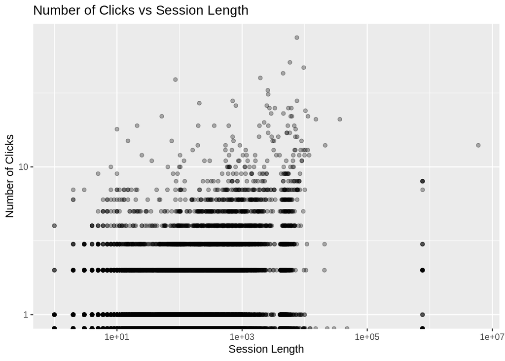

```r
sessions %>%
  ggplot(aes(x = session_length, y = sum_num_clicks)) +
  geom_point(alpha = .3) +
  scale_x_log10() +
  scale_y_log10() +
  labs(x = "Session Length",
       y = "Number of Clicks",
       title="Number of Clicks vs Session Length")
```